# Dissecting the DCN-V2 Cross Layer

Joseph Bolton

10 August, 2021

[output not shown]

[output cut: 20 more lines]

[output not shown]

*Feature Crossing* is a simple but powerful method used to create new features, by combining existing features.

The *DCN cross layer*, described first in [this paper](https://dl.acm.org/doi/10.1145/3124749.3124754) and expanded in [this paper](https://arxiv.org/abs/2008.13535), is an elegant method for automatic creation and selection of predictive feature crosses within a neural network model. Note that this is by no means the only automated feature-crossing solution that has been proposed (e.g. [Factorisation Machines](https://www.csie.ntu.edu.tw/~b97053/paper/Rendle2010FM.pdf), [DeepFM](https://paperswithcode.com/paper/deepfm-a-factorization-machine-based-neural), [DNN2LR](https://arxiv.org/abs/2102.12036), [AutoCross](https://arxiv.org/abs/1904.12857) etc.).

Although the notation of the cross layer is quite straightforward, the precise behaviour of the layer wasn’t immediately apparent to me, especially where multiple cross layers are stacked in sequence. So, in pursuit of a deeper understanding, I explicitly wrote out the output of 3 sequential cross layers for a simple 3-dimensional input vector. I’ve published it here in the hope that it will clear things up for you as it did for me.

What follows:

1. Two examples of feature crossing, to illustrate what *feature crossing* is
2. A diagram of the structure of the DCN-V2 cross layer
3. The cross layer written out explicitly for an example input

Note that in application, cross layers usually appear in sequence and/or in parallel with other sorts of neural network layers such as dense layers.

# 1. Two Examples of Feature Crossing

Features are *crossed* simply by multiplying their values together.

Here is an example of a feature (**prob_X_expected**) created by *crossing* 2 numeric features:

| prob_to_transact | expected_spend_if_transact | prob_X_expected |
| --- | --- | --- |
| 0.93 | 5.95 | 5.5335 |
| 0.12 | 31.54 | 3.7848 |
| 0.90 | 35.87 | 32.2830 |
| 0.62 | 326.51 | 202.4362 |
| 0.55 | 23.82 | 13.1010 |
| 0.37 | 26.14 | 9.6718 |
| 0.39 | 15.47 | 6.0333 |
| 0.36 | 30.85 | 11.1060 |
| 0.14 | 26.09 | 3.6526 |
| 0.63 | 44.33 | 27.9279 |

Here is an example of a new feature (**gender_X_location**) created by *crossing* 2 categorical features:

| gender | location | gender_X_location |
| --- | --- | --- |
| female | Europe | female_Europe |
| female | Africa | female_Africa |
| male | Europe | male_Europe |
| male | Africa | male_Africa |

| gender_male | gender_female | location_Africa | location_Europe | male_X_Africa | male_X_Europe | female_X_Africa | female_X_Europe |
| --- | --- | --- | --- | --- | --- | --- | --- |
| 0 | 1 | 0 | 1 | 0 | 0 | 0 | 1 |
| 0 | 1 | 1 | 0 | 0 | 0 | 1 | 0 |
| 1 | 0 | 0 | 1 | 0 | 1 | 0 | 0 |
| 1 | 0 | 1 | 0 | 1 | 0 | 0 | 0 |

# 2. A Diagram of the Structure of the Cross Layer

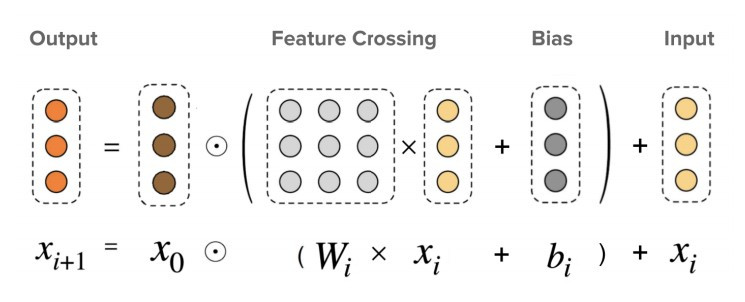

(from the original DCN-V2 paper)

# 3. The Cross Layer Written Out Explicitly for an Example Input

$$\begin{array}{lcl}
x_{l+1} &=& x_0 \odot (W_l x_l + b_l) + x_l \\
x_0 &=& \begin{bmatrix}
\color{orange}{a} \\
\color{green}{b} \\
\color{brown}{c} \\
\end{bmatrix}
\\
x_1
&=&
x_0 \odot (W_0 x_0 + b_0) + x_0 \\
&=&
\begin{bmatrix}
\color{orange}{a} \\
\color{green}{b} \\
\color{brown}{c} \\
\end{bmatrix}
\odot
\Bigg(
\begin{bmatrix}
{^0}w_{11} & {^0}w_{12} & {^0}w_{13} \\
{^0}w_{21} & {^0}w_{22} & {^0}w_{23} \\
{^0}w_{31} & {^0}w_{32} & {^0}w_{33} \\
\end{bmatrix}
\begin{bmatrix}
\color{orange}{a} \\
\color{green}{b} \\
\color{brown}{c} \\
\end{bmatrix}
+
\begin{bmatrix}
{^0}b_1 \\ {^0}b_2 \\ {^0}b_3 \\
\end{bmatrix}
\Bigg)
+
\begin{bmatrix}
\color{orange}{a} \\
\color{green}{b} \\
\color{brown}{c} \\
\end{bmatrix}
\\
&=&
\begin{bmatrix}
\color{orange}{a}(
{^0}w_{11}\color{orange}{a} +
{^0}w_{12}\color{green}{b} +
{^0}w_{13}\color{brown}{c}
+
{^0}b_1
)
+
\color{orange}{a}
\\
\color{green}{b}(
{^0}w_{21}\color{orange}{a} +
{^0}w_{22}\color{green}{b} +
{^0}w_{23}\color{brown}{c}
+
{^0}b_2
)
+
\color{green}{b}
\\
\color{brown}{c}(
{^0}w_{31}\color{orange}{a} +
{^0}w_{32}\color{green}{b} +
{^0}w_{33}\color{brown}{c}
+
{^0}b_3
)
+
\color{brown}{c}
\end{bmatrix}
\\
&=&
\begin{bmatrix}
{^0}w_{11}\color{orange}{a^2} +
{^0}w_{12}\color{orange}{a}\color{green}{b} +
{^0}w_{13}\color{orange}{a}\color{brown}{c}
+
\color{orange}{a}({^0}b_1+1)
\\
{^0}w_{21}\color{orange}{a}\color{green}{b} +
{^0}w_{22}\color{green}{b^2} +
{^0}w_{23}\color{green}{b}\color{brown}{c}
+
\color{green}{b}({^0}b_2+1)
\\
{^0}w_{31}\color{orange}{a}\color{brown}{c} +
{^0}w_{32}\color{green}{b}\color{brown}{c} +
{^0}w_{33}\color{brown}{c^2}
+
\color{brown}{c}( {^0}b_3+1 )
)
\end{bmatrix}
\\
x_2
&=&
x_0 \odot (W_1 x_1 + b_1 ) + x_1 \\
&=&
\underset{x_0}{
\underbrace{
\begin{bmatrix}
\color{orange}{a} \\
\color{green}{b} \\
\color{brown}{c} \\
\end{bmatrix}
}
}
\odot
\Bigg(
\underset{W_1}{
\underbrace{
\begin{bmatrix}
{^1}w_{11} & {^1}w_{12} & {^1}w_{13} \\
{^1}w_{21} & {^1}w_{22} & {^1}w_{23} \\
{^1}w_{31} & {^1}w_{32} & {^1}w_{33} \\
\end{bmatrix}
}
}
\underset{x_1}{
\underbrace{
\begin{bmatrix}
{^0}w_{11}\color{orange}{a^2} +
{^0}w_{12}\color{orange}{a}\color{green}{b} +
{^0}w_{13}\color{orange}{a}\color{brown}{c}
+
\color{orange}{a}({^0}b_1+1)
\\
{^0}w_{21}\color{orange}{a}\color{green}{b} +
{^0}w_{22}\color{green}{b^2} +
{^0}w_{23}\color{green}{b}\color{brown}{c}
+
\color{green}{b}({^0}b_2+1)
\\
{^0}w_{31}\color{orange}{a}\color{brown}{c} +
{^0}w_{32}\color{green}{b}\color{brown}{c} +
{^0}w_{33}\color{brown}{c^2}
+
\color{brown}{c}( {^0}b_3+1 )
)
\end{bmatrix}
}
}
+
\underset{b_1}{
\underbrace{
\begin{bmatrix}
{^1}b_1 \\ {^1}b_2 \\ {^1}b_3 \\
\end{bmatrix}
}
}
\Bigg)
+
\underset{x_1}{
\underbrace{
\begin{bmatrix}
{^0}w_{11}\color{orange}{a^2} +
{^0}w_{12}\color{orange}{a}\color{green}{b} +
{^0}w_{13}\color{orange}{a}\color{brown}{c}
+
\color{orange}{a}({^0}b_1+1)
\\
{^0}w_{21}\color{orange}{a}\color{green}{b} +
{^0}w_{22}\color{green}{b^2} +
{^0}w_{23}\color{green}{b}\color{brown}{c}
+
\color{green}{b}({^0}b_2+1)
\\
{^0}w_{31}\color{orange}{a}\color{brown}{c} +
{^0}w_{32}\color{green}{b}\color{brown}{c} +
{^0}w_{33}\color{brown}{c^2}
+
\color{brown}{c}( {^0}b_3+1 )
)
\end{bmatrix}
}
}
\\
&=&
\begin{bmatrix}
\color{orange}{a} \\
\color{green}{b} \\
\color{brown}{c} \\
\end{bmatrix}
\odot
\begin{bmatrix}
{^1}w_{11}(
{^0}w_{11}\color{orange}{a^2} +
{^0}w_{12}\color{orange}{a}\color{green}{b} +
{^0}w_{13}\color{orange}{a}\color{brown}{c}
+
\color{orange}{a}{^0}b_1+\color{orange}{a}
)
+
{^1}w_{12}(
{^0}w_{21}\color{orange}{a}\color{green}{b} +
{^0}w_{22}\color{green}{b^2} +
{^0}w_{23}\color{green}{b}\color{brown}{c}
+
\color{green}{b}{^0}b_2 + \color{green}{b}
) +
{^1}w_{13}(
{^0}w_{31}\color{orange}{a}\color{brown}{c} +
{^0}w_{32}\color{green}{b}\color{brown}{c} +
{^0}w_{33}\color{brown}{c^2}
+
\color{brown}{c}{^0}b_3 + \color{brown}{c}
)
+
{^1}b_1
\\
{^1}w_{21}(
{^0}w_{11}\color{orange}{a^2} +
{^0}w_{12}\color{orange}{a}\color{green}{b} +
{^0}w_{13}\color{orange}{a}\color{brown}{c}
+
\color{orange}{a}{^0}b_1+\color{orange}{a}
)
+
{^1}w_{22}(
{^0}w_{21}\color{orange}{a}\color{green}{b} +
{^0}w_{22}\color{green}{b^2} +
{^0}w_{23}\color{green}{b}\color{brown}{c}
+
\color{green}{b}{^0}b_2 + \color{green}{b}
) +
{^1}w_{23}(
{^0}w_{31}\color{orange}{a}\color{brown}{c} +
{^0}w_{32}\color{green}{b}\color{brown}{c} +
{^0}w_{33}\color{brown}{c^2}
+
\color{brown}{c}{^0}b_3 + \color{brown}{c}
)
+
{^1}b_2
\\
{^1}w_{31}(
{^0}w_{11}\color{orange}{a^2} +
{^0}w_{12}\color{orange}{a}\color{green}{b} +
{^0}w_{13}\color{orange}{a}\color{brown}{c}
+
\color{orange}{a}{^0}b_1+\color{orange}{a}
)
+
{^1}w_{32}(
{^0}w_{21}\color{orange}{a}\color{green}{b} +
{^0}w_{22}\color{green}{b^2} +
{^0}w_{23}\color{green}{b}\color{brown}{c}
+
\color{green}{b}{^0}b_2 + \color{green}{b}
) +
{^1}w_{33}(
{^0}w_{31}\color{orange}{a}\color{brown}{c} +
{^0}w_{32}\color{green}{b}\color{brown}{c} +
{^0}w_{33}\color{brown}{c^2}
+
\color{brown}{c}{^0}b_3 + \color{brown}{c}
)
+
{^1}b_3
\end{bmatrix}
+
\begin{bmatrix}
{^0}w_{11}\color{orange}{a^2} +
{^0}w_{12}\color{orange}{a}\color{green}{b} +
{^0}w_{13}\color{orange}{a}\color{brown}{c}
+
\color{orange}{a}({^0}b_1+1)
\\
{^0}w_{21}\color{orange}{a}\color{green}{b} +
{^0}w_{22}\color{green}{b^2} +
{^0}w_{23}\color{green}{b}\color{brown}{c}
+
\color{green}{b}({^0}b_2+1)
\\
{^0}w_{31}\color{orange}{a}\color{brown}{c} +
{^0}w_{32}\color{green}{b}\color{brown}{c} +
{^0}w_{33}\color{brown}{c^2}
+
\color{brown}{c}( {^0}b_3+1 )
\end{bmatrix}
\\
&=&
\begin{bmatrix}
{^1}w_{11}(
{^0}w_{11}\color{orange}{a^3} +
{^0}w_{12}\color{orange}{a^2}\color{green}{b} +
{^0}w_{13}\color{orange}{a^2}\color{brown}{c}
+
{^0}b_1\color{orange}{a^2} + \color{orange}{a^2}
)
+
{^1}w_{12}(
{^0}w_{21}\color{orange}{a^2}\color{green}{b} +
{^0}w_{22}\color{orange}{a}\color{green}{b^2} +
{^0}w_{23}\color{orange}{a}\color{green}{b}\color{brown}{c}
+
{^0}b_2\color{orange}{a}\color{green}{b} + \color{orange}{a}\color{green}{b}
) +
{^1}w_{13}(
{^0}w_{31}\color{orange}{a^2}\color{brown}{c} +
{^0}w_{32}\color{orange}{a}\color{green}{b}\color{brown}{c} +
{^0}w_{33}\color{orange}{a}\color{brown}{c^2}
+
{^0}b_3\color{orange}{a}\color{brown}{c} + \color{orange}{a}\color{brown}{c}
)
+
{^1}b_1 \color{orange}{a}
+
{^0}w_{11}\color{orange}{a^2} +
{^0}w_{12}\color{orange}{a}\color{green}{b} +
{^0}w_{13}\color{orange}{a}\color{brown}{c}
+
\color{orange}{a}({^0}b_1+1)
\\
{^1}w_{21}(
{^0}w_{11}\color{orange}{a^2}\color{green}{b} +
{^0}w_{12}\color{orange}{a}\color{green}{b^2} +
{^0}w_{13}\color{orange}{a}\color{green}{b}\color{brown}{c}
+
{^0}b_1\color{orange}{a}\color{green}{b} + \color{orange}{a}\color{green}{b}
)
+
{^1}w_{22}(
{^0}w_{21}\color{orange}{a}\color{green}{b^2} +
{^0}w_{22}\color{green}{b^3} +
{^0}w_{23}\color{green}{b^2}\color{brown}{c}
+
{^0}b_2\color{green}{b^2} + \color{green}{b^2}
) +
{^1}w_{23}(
{^0}w_{31}\color{orange}{a}\color{green}{b}\color{brown}{c} +
{^0}w_{32}\color{green}{b^2}\color{brown}{c} +
{^0}w_{33}\color{green}{b}\color{brown}{c^2}
+
{^0}b_3\color{green}{b}\color{brown}{c} + \color{green}{b}\color{brown}{c}
)
+
{^1}b_2\color{green}{b}
+
{^0}w_{21}\color{orange}{a}\color{green}{b} +
{^0}w_{22}\color{green}{b^2} +
{^0}w_{23}\color{green}{b}\color{brown}{c}
+
\color{green}{b}({^0}b_2+1)
\\
{^1}w_{31}(
{^0}w_{11}\color{orange}{a^2}\color{brown}{c} +
{^0}w_{12}\color{orange}{a}\color{green}{b}\color{brown}{c} +
{^0}w_{13}\color{orange}{a}\color{brown}{c^2}
+
{^0}b_1\color{orange}{a}\color{brown}{c} + \color{orange}{a}\color{brown}{c}
)
+
{^1}w_{32}(
{^0}w_{21}\color{orange}{a}\color{green}{b}\color{brown}{c} +
{^0}w_{22}\color{green}{b^2}\color{brown}{c} +
{^0}w_{23}\color{green}{b}\color{brown}{c^2}
+
{^0}b_2\color{green}{b}\color{brown}{c} + \color{green}{b}\color{brown}{c}
) +
{^1}w_{33}(
{^0}w_{31}\color{orange}{a}\color{brown}{c^2} +
{^0}w_{32}\color{green}{b}\color{brown}{c^2} +
{^0}w_{33}\color{brown}{c^3}
+
{^0}b_3\color{brown}{c^2} + \color{brown}{c^2}
)
+
{^1}b_3\color{brown}{c}
+
{^0}w_{31}\color{orange}{a}\color{brown}{c} +
{^0}w_{32}\color{green}{b}\color{brown}{c} +
{^0}w_{33}\color{brown}{c^2}
+
\color{brown}{c}( {^0}b_3+1 )
\end{bmatrix}
\\
x_3
&=&
x_0 \odot (W_2 x_2 + b_2 ) + x_2 \\
&=&
\underset{x_0}{
\underbrace{
\begin{bmatrix}
\color{orange}{a} \\
\color{green}{b} \\
\color{brown}{c} \\
\end{bmatrix}
}
}
\odot
\Bigg(
\underset{W_2}{
\underbrace{
\begin{bmatrix}
{^2}w_{11} & {^2}w_{12} & {^2}w_{13} \\
{^2}w_{21} & {^2}w_{22} & {^2}w_{23} \\
{^2}w_{31} & {^2}w_{32} & {^2}w_{33} \\
\end{bmatrix}
}
}
\underset{x_2}{
\underbrace{
\begin{bmatrix}
. \\ . \\ .
\end{bmatrix}
}
}
+
\underset{b_2}{
\underbrace{
\begin{bmatrix}
{^2}b_1 \\ {^2}b_2 \\ {^2}b_3 \\
\end{bmatrix}
}
}
\Bigg)
+
\underset{x_2}{
\underbrace{
\begin{bmatrix}
. \\ . \\ .
\end{bmatrix}
}
}
\end{array}$$

If you don’t trust my algebra, here is a quick validation of my calculation using **R**:

```r
# validate my calculation:
a <- -1
b <- 4
c <- 9
x0 <- matrix( c(a, b, c), nrow=3, ncol=1 )
w0 <- matrix( sample( -100:100, size=9, replace=TRUE),
              nrow = 3,
              ncol = 3
            )
b0 <- matrix( sample( -100:100, size=3, replace=TRUE),
              nrow = 3,
              ncol = 1
            )
w1 <- matrix( sample( -100:100, size=9, replace=TRUE),
              nrow = 3,
              ncol = 3
            )
b1 <- matrix( sample( -100:100, size=3, replace=TRUE),
              nrow = 3,
              ncol = 1
            )

x1 <- x0 * ( w0%*%x0 + b0 ) + x0
x2 <- x0 * ( w1%*%x1 + b1 ) + x1

x2
```

```
##         [,1]
## [1,]  130295
## [2,] 2871700
## [3,] -352647
```

```r
c(
    w1[1,1]*( w0[1,1]*a^3 + w0[1,2]*a^2*b + w0[1,3]*a^2*c + b0[1]*a^2 + a^2 ) +
    w1[1,2]*( w0[2,1]*a^2*b + w0[2,2]*a*b^2 + w0[2,3]*a*b*c + b0[2]*a*b + a*b ) +
    w1[1,3]*( w0[3,1]*a^2*c + w0[3,2]*a*b*c + w0[3,3]*a*c^2 + b0[3]*a*c + a*c) +
    b1[1]*a +
    w0[1,1]*a^2 +
    w0[1,2]*a*b +
    w0[1,3]*a*c +
    a * (b0[1] + 1)
    ,
    w1[2,1]*( w0[1,1]*a^2*b + w0[1,2]*a*b^2 + w0[1,3]*a*b*c + b0[1]*a*b + a*b ) +
    w1[2,2]*( w0[2,1]*a*b^2 + w0[2,2]*b^3 + w0[2,3]*b^2*c + b0[2]*b^2 + b^2 ) +
    w1[2,3]*( w0[3,1]*a*b*c + w0[3,2]*b^2*c + w0[3,3]*b*c^2 + b0[3]*b*c + b*c) +
    b1[2]*b +
    w0[2,1]*a*b +
    w0[2,2]*b^2 +
    w0[2,3]*b*c +
    b * (b0[2] + 1)
    ,
    w1[3,1]*( w0[1,1]*a^2*c + w0[1,2]*a*b*c + w0[1,3]*a*c^2 + b0[1]*a*c + a*c ) +
    w1[3,2]*( w0[2,1]*a*b*c + w0[2,2]*b^2*c + w0[2,3]*b*c^2 + b0[2]*b*c + b*c ) +
    w1[3,3]*( w0[3,1]*a*c^2 + w0[3,2]*b*c^2 + w0[3,3]*c^3 + b0[3]*c^2 + c^2) +
    b1[3]*c +
    w0[3,1]*a*c +
    w0[3,2]*b*c +
    w0[3,3]*c^2 +
    c * (b0[3] + 1)

)
```

```
## [1]  130295 2871700 -352647
```